# Forecasting Study of House Sales

## Introduction

In this study, a specific relation will be analysed which is between first hand house sales and some regressors such as economic situation of households and interest rates of housing credits. Then, useful data (from 01.2016 to 03.2021) will be utilized in linear regression analysis so that the forecast for the sale quantity of 04-2021 will be performed. In addition, visual analysis will be used in each step to enhance the arguments and interpret the results in an easier way. Data used in this work could be reached (here)[https://evds2.tcmb.gov.tr/]

## Preparation of the Data

In this step, data is prepared to use and 3 aspects have been changed as time series objects for the purpose of having better interpretation. These 3 aspects are quantity of house sales, interest rates of housing credits and the results of the survey for the economic situation of households in Turkey.

```r
library(readxl)
library(fpp)
library(ggplot2)
library(data.table)
frame=read_excel("C:/Users/mfdevecii/Desktop/Sales.xlsx")
mytable=as.data.table(frame)
sales=ts(mytable$`House_Sales`, frequency = 12, start=c(2016,1) )
interest=ts(mytable$`Interest`, frequency = 12, start=c(2016,1) )
econ=ts(mytable$`Economy`, frequency = 12, start=c(2016,1) )
```

## Preliminary Visualisation and Interpretation

# House Sales

The quantities of the sale as first hand is below:

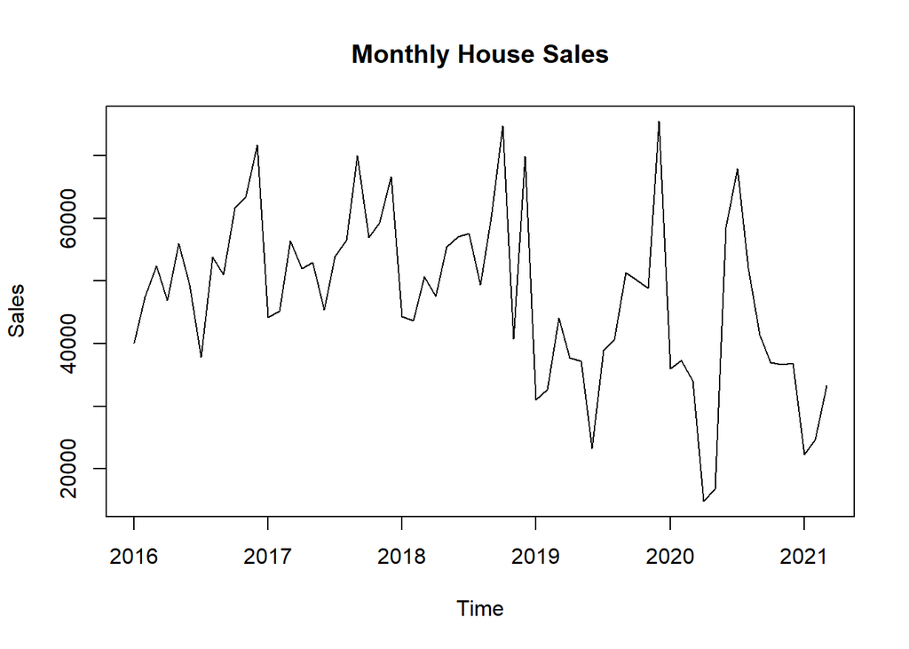

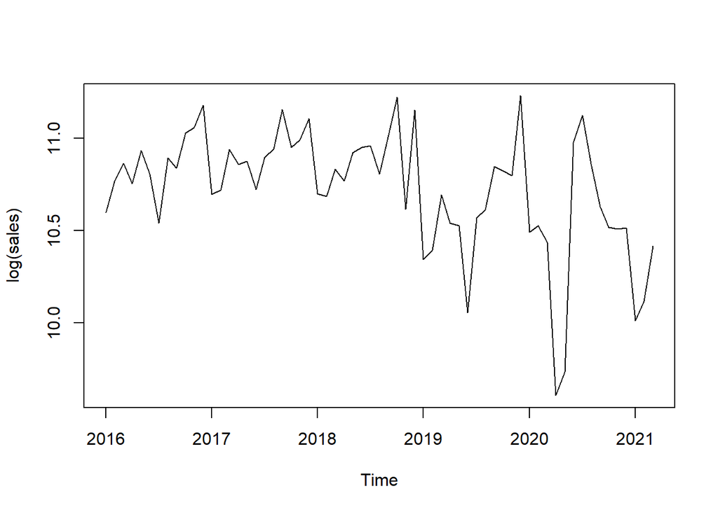

As an alternative idea, the deterioration around 2020 must be examined. After some research, it could be said that Covid-19 has appeared in Turkey after 03-2020. Hence, citizens felt in chaos and did not have tendency to buy a new house. The effects of covid-19 should be smoothed. In order to smooth the sudden decrease of sales, model will be built after some operations, which are having the mean of previous years for the same months and assign those numbers to 04-2020 and 05-2020. Before going into these operations, trend and month columns is added into model to make each operations easier and interpret the time series.

```r
mytable[,trend:=1:.N] # Trend is added into model also for making operations easier.
month=1:12
mytable=cbind(mytable,month)
```

Now that it is easier to perform smoothing, operation could be done this way:

```r
mytable[trend %between% c(52,53),is_covid:=1] # Checks months that covid-19 has huge impact
mytable[is.na(is_covid)==TRUE, is_covid:=0]   # Checks usual months
count1=0;
count2=0
for(i in 1:63) {
  if(mytable[i,7]==0 & mytable[i,6]==4){
    count1=count1+mytable[i,2]
  }
}
for(i in 1:63) {
  if(mytable[i,7]==0 & mytable[i,6]==5){
    count2=count2+mytable[i,2]
  }
}
count1=count1/4  # Mean of previous 4 years
count2=count2/4  # Mean of previous 4 years
mytable[52,2]=count1  #Assignment
mytable[53,2]=count2  #Assignment
sales=ts(mytable$`House_Sales`, frequency = 12, start=c(2016,1) ) # Retrieve the time series version
```

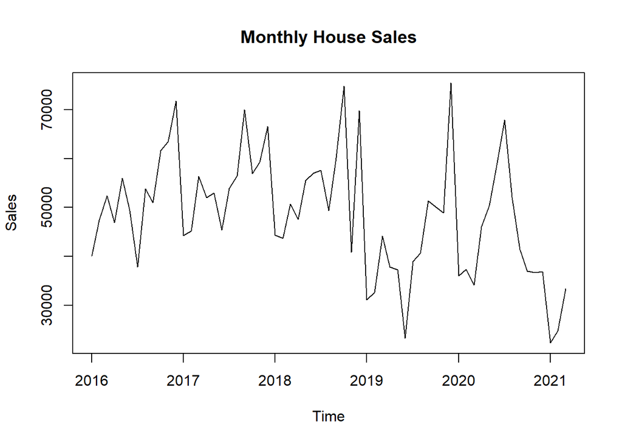

Furthermore, model is still not ready to be used in linear regression because of the decrease in the period after 01-2021. According to (chairman of INDER)[https://www.emlakgundemi.com.tr/gundem/konut-satislarindaki-dususun-sebepleri-neler-h21385.html], %34 decrease in the sales stems from weekend restrictions. Due to not having restrictions anymore, model has to be changed on that period. I.E, unexpected decreases must be smoothed by assuming restrictions were did not taken so that forecast for 04-2021 makes more sense.

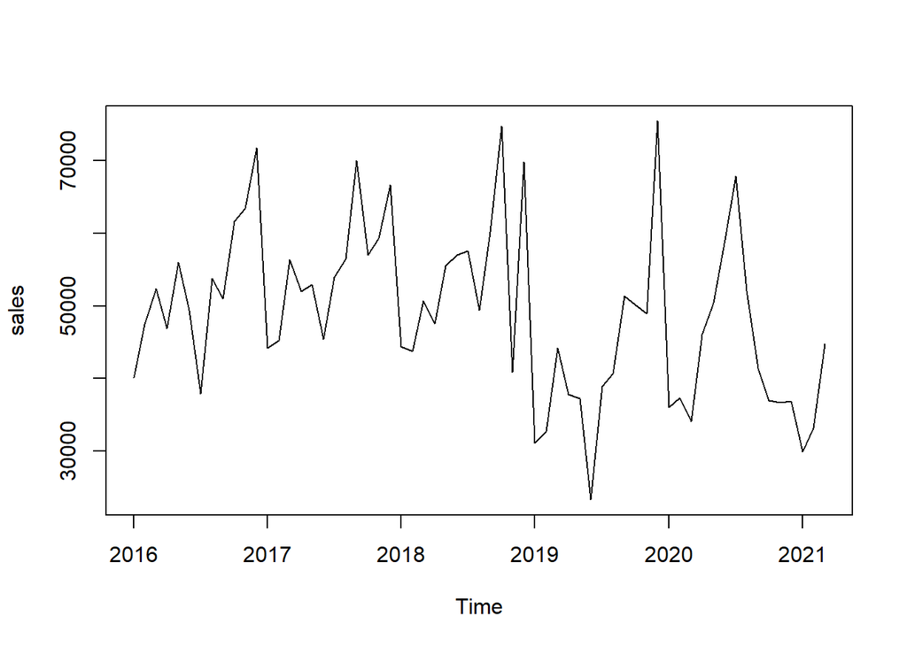

```r
mytable[61,2]=1.34*mytable[61,2]  #Assignment for 01-2021
mytable[62,2]=1.34*mytable[62,2]  #Assignment for 02-2021
mytable[63,2]=1.34*mytable[63,2]  #Assignment for 03-2021
sales=ts(mytable$`House_Sales`, frequency = 12, start=c(2016,1) )
plot(sales)
```

As it is clearly seen, variance is more stable now.

# Interest Rates

The rates of the interest for housing credits are below:

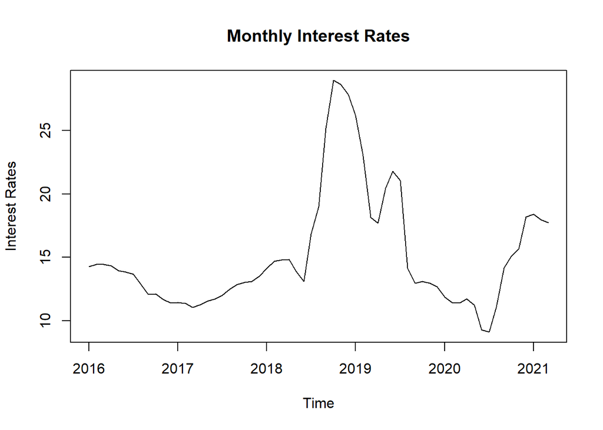

# Economic Situation of Households

The result of the survey which reflects economic situation and expectation of people in Turkey is below:

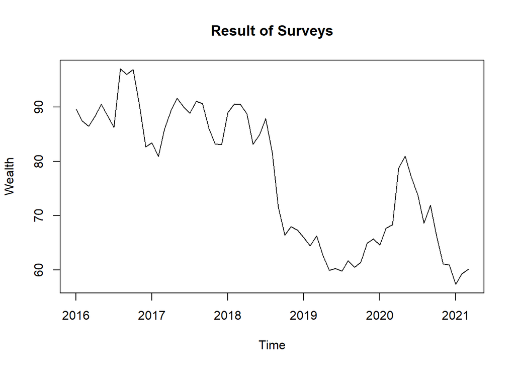

## Creation of Regression Model

Linear regressions will be implemented consecutively in 4 steps so final regression model will be obtained.

# Step 1

In step 1, only trend is added as independent variable.

```r
fit1 = lm(House_Sales~trend, data = mytable)
summary(fit1)
```

```
##
## Call:
## lm(formula = House_Sales ~ trend, data = mytable)
##
## Residuals:
##      Min       1Q   Median       3Q      Max
## -23878.0  -7759.8   -390.2   5782.7  29545.2
##
## Coefficients:
##             Estimate Std. Error t value Pr(>|t|)
## (Intercept) 55599.90    2839.60   19.58   <2e-16 ***
## trend        -201.36      77.15   -2.61   0.0114 *
## ---
## Signif. codes:  0 '***' 0.001 '**' 0.01 '*' 0.05 '.' 0.1 ' ' 1
##
## Residual standard error: 11140 on 61 degrees of freedom
## Multiple R-squared:  0.1004, Adjusted R-squared:  0.0857
## F-statistic: 6.812 on 1 and 61 DF,  p-value: 0.01138
```

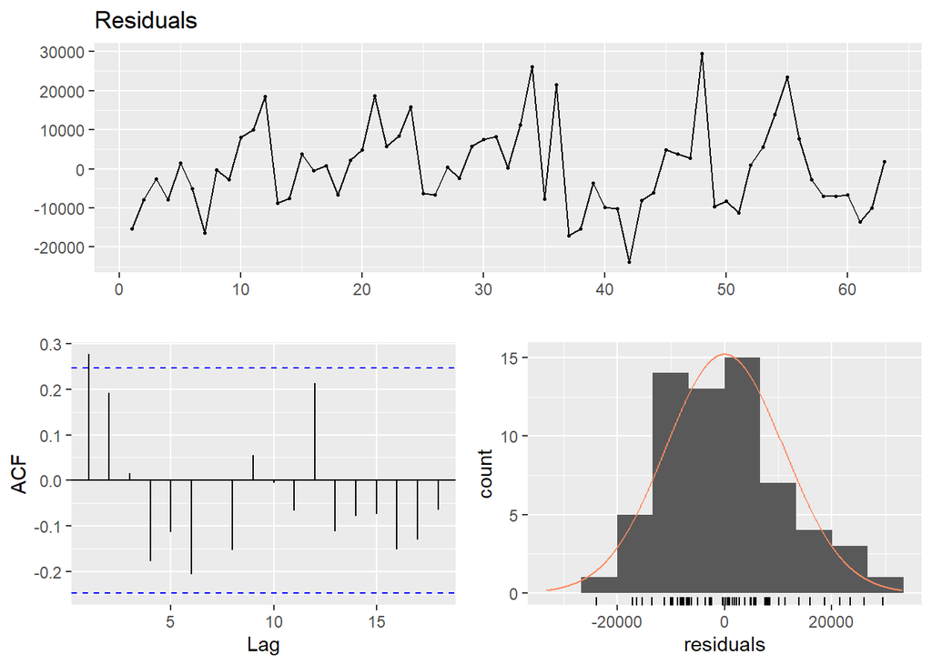

```
##
##  Breusch-Godfrey test for serial correlation of order up to 12
##
## data:  Residuals
## LM test = 16.082, df = 12, p-value = 0.1875
```

```r
checkresiduals(fit1,lag=12)
```

To interpret, R-squared and Adjusted R-squared values are really low. Autocorellation is quite low but model still needs to be enhanced because of low R-square values and violated normality assumption of residuals.

# Step 2

In order to increase R-squared values and get more decent residuals, month variable is added into the system.

```r
fit2 = lm(House_Sales~trend+as.factor(month), data = mytable)
summary(fit2)
```

```
##
## Call:
## lm(formula = House_Sales ~ trend + as.factor(month), data = mytable)
##
## Residuals:
##      Min       1Q   Median       3Q      Max
## -21725.0  -4539.2     85.9   5115.5  22199.8
##
## Coefficients:
##                    Estimate Std. Error t value Pr(>|t|)
## (Intercept)        44724.39    4305.40  10.388 4.40e-14 ***
## trend               -229.81      65.05  -3.533 0.000895 ***
## as.factor(month)2   2535.38    5380.06   0.471 0.639508
## as.factor(month)3   9927.95    5381.24   1.845 0.070976 .
## as.factor(month)4   7763.72    5645.61   1.375 0.175207
## as.factor(month)5  12381.78    5643.74   2.194 0.032918 *
## as.factor(month)6   8919.44    5642.62   1.581 0.120246
## as.factor(month)7  13652.25    5642.24   2.420 0.019214 *
## as.factor(month)8  13109.65    5642.62   2.323 0.024269 *
## as.factor(month)9  17655.06    5643.74   3.128 0.002931 **
## as.factor(month)10 19217.67    5645.61   3.404 0.001316 **
## as.factor(month)11 13160.68    5648.24   2.330 0.023881 *
## as.factor(month)12 27687.08    5651.61   4.899 1.05e-05 ***
## ---
## Signif. codes:  0 '***' 0.001 '**' 0.01 '*' 0.05 '.' 0.1 ' ' 1
##
## Residual standard error: 9318 on 50 degrees of freedom
## Multiple R-squared:  0.4837, Adjusted R-squared:  0.3598
## F-statistic: 3.904 on 12 and 50 DF,  p-value: 0.0003111
```

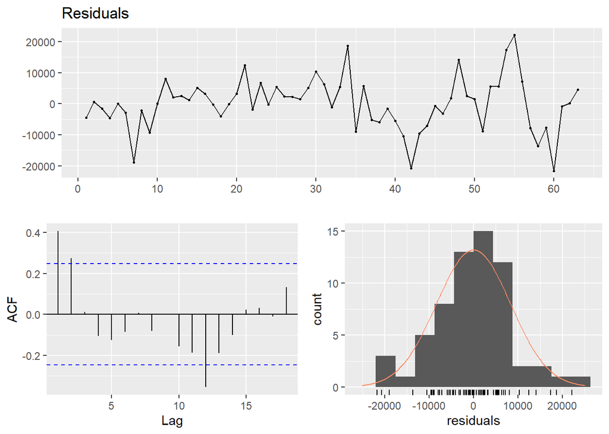

```
##
##  Breusch-Godfrey test for serial correlation of order up to 12
##
## data:  Residuals
## LM test = 26.405, df = 12, p-value = 0.009404
```

```r
checkresiduals(fit2,lag=12)
```

To interpret, R-squared and Adjusted R-squared values increased. However, autocorellation has increased too. The model in this step needs to be improved because Breusch-Godfrey test tells there is autocorrelation (low p-value).

# Step 3

In this step, 2 indicators having possibility to affect sale quantities are added into model. Interest rates and economic indicator of citizens have changed graphs and improved the model in a good way.

```r
fit3 = lm(House_Sales~trend+as.factor(month)+Interest+Economy, data = mytable)
summary(fit3)
```

```
##
## Call:
## lm(formula = House_Sales ~ trend + as.factor(month) + Interest +
##     Economy, data = mytable)
##
## Residuals:
##      Min       1Q   Median       3Q      Max
## -22598.3  -3020.2    142.8   2962.0  23571.4
##
## Coefficients:
##                    Estimate Std. Error t value Pr(>|t|)
## (Intercept)         1345.03   20644.42   0.065  0.94832
## trend                 30.77     114.72   0.268  0.78964
## as.factor(month)2   2212.55    5026.39   0.440  0.66178
## as.factor(month)3   8720.11    5044.16   1.729  0.09028 .
## as.factor(month)4   5280.34    5334.32   0.990  0.32720
## as.factor(month)5   9808.45    5337.51   1.838  0.07231 .
## as.factor(month)6   6600.41    5324.30   1.240  0.22112
## as.factor(month)7  11492.76    5316.21   2.162  0.03565 *
## as.factor(month)8  10329.25    5347.24   1.932  0.05931 .
## as.factor(month)9  15595.74    5319.88   2.932  0.00515 **
## as.factor(month)10 18242.42    5290.59   3.448  0.00118 **
## as.factor(month)11 12812.87    5277.43   2.428  0.01899 *
## as.factor(month)12 27870.62    5278.79   5.280 3.09e-06 ***
## Interest             -45.71     291.52  -0.157  0.87606
## Economy              480.63     192.43   2.498  0.01598 *
## ---
## Signif. codes:  0 '***' 0.001 '**' 0.01 '*' 0.05 '.' 0.1 ' ' 1
##
## Residual standard error: 8701 on 48 degrees of freedom
## Multiple R-squared:  0.5678, Adjusted R-squared:  0.4417
## F-statistic: 4.504 on 14 and 48 DF,  p-value: 4.356e-05
```

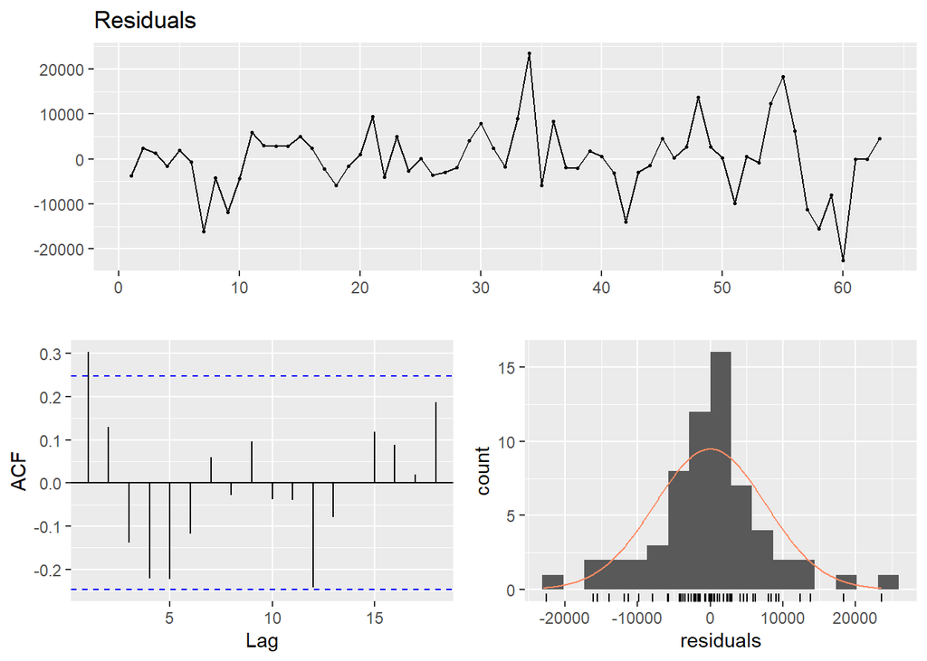

```
##
##  Breusch-Godfrey test for serial correlation of order up to 12
##
## data:  Residuals
## LM test = 22.597, df = 12, p-value = 0.03135
```

```r
checkresiduals(fit3,lag=12)
```

Now that new independent variables are added, autocorrelation has changed as it is expected. Autocorrelation lower in this step but it still exist if alpha value is taken as 0.05. Moreover, the model has less residual standard error and higher R-squared values, which means model has been sophisticated. But as the last step, it is needed to find residual autocorrelation where it stands at most. So the code below is used:

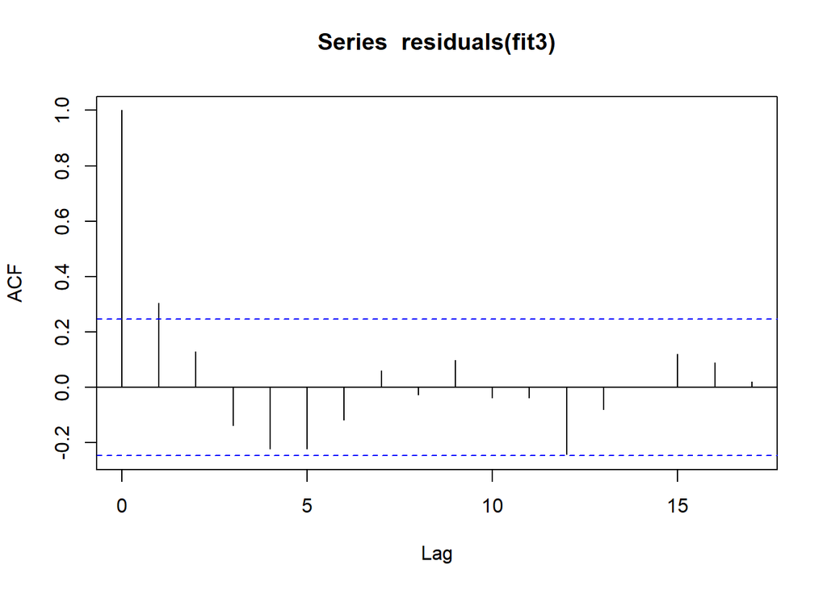

```r
acf(residuals(fit3))
```

As it is seen, residuals need to be arrenged by lag1 or lag 12 but in this model lag1 gives the best result in terms of having better parameters (higher R-squared values, lower residual standard errors and fitting more to normality assumption of residuals).

# Step 4

As it is mentioned above, lag1 value is added into data table and model in this step. Hence regression result has lower autocorrelated residuals, better variance of residuals and better mean which is closer to 0 (compared to step1,step2,step3).

```r
mytable[, residuals:=residuals(fit3)]
mytable[, lag1:=shift(residuals(fit3),1)]
ffit= lm(House_Sales~trend+as.factor(month)+Interest+Economy+lag1, data = mytable)
summary(ffit)
```

```
##
## Call:
## lm(formula = House_Sales ~ trend + as.factor(month) + Interest +
##     Economy + lag1, data = mytable)
##
## Residuals:
##      Min       1Q   Median       3Q      Max
## -20076.2  -2777.8     23.1   3402.9  21090.5
##
## Coefficients:
##                      Estimate Std. Error t value Pr(>|t|)
## (Intercept)         1587.5834 20263.4169   0.078  0.93789
## trend                 32.3436   112.9081   0.286  0.77581
## as.factor(month)2   1432.2658  5125.7922   0.279  0.78117
## as.factor(month)3   7913.1592  5136.3711   1.541  0.13026
## as.factor(month)4   4703.0869  5421.3252   0.868  0.39016
## as.factor(month)5   8954.0825  5418.1639   1.653  0.10522
## as.factor(month)6   5751.0828  5404.1952   1.064  0.29280
## as.factor(month)7  10658.6720  5391.6331   1.977  0.05407 .
## as.factor(month)8   9477.4353  5415.5209   1.750  0.08678 .
## as.factor(month)9  14783.9319  5384.8502   2.745  0.00859 **
## as.factor(month)10 17470.2741  5356.0285   3.262  0.00209 **
## as.factor(month)11 12056.2791  5343.3444   2.256  0.02885 *
## as.factor(month)12 27132.7521  5342.5153   5.079 6.75e-06 ***
## Interest             -60.8578   283.1683  -0.215  0.83078
## Economy              490.2527   187.0713   2.621  0.01185 *
## lag1                   0.3056     0.1408   2.170  0.03518 *
## ---
## Signif. codes:  0 '***' 0.001 '**' 0.01 '*' 0.05 '.' 0.1 ' ' 1
##
## Residual standard error: 8445 on 46 degrees of freedom
##   (1 observation deleted due to missingness)
## Multiple R-squared:  0.6059, Adjusted R-squared:  0.4774
## F-statistic: 4.715 on 15 and 46 DF,  p-value: 2.31e-05
```

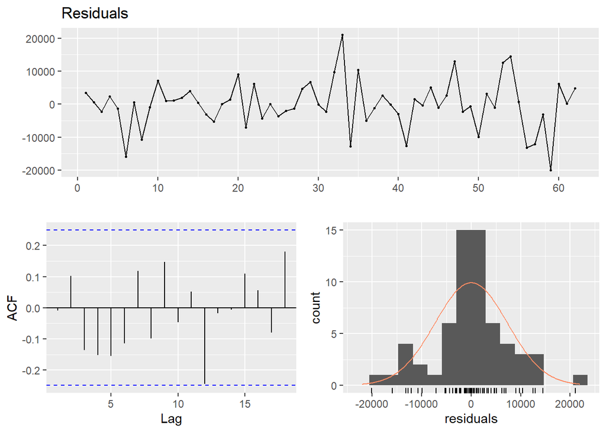

```
##
##  Breusch-Godfrey test for serial correlation of order up to 12
##
## data:  Residuals
## LM test = 17.773, df = 12, p-value = 0.1228
```

```r
checkresiduals(ffit,lag=12)
```

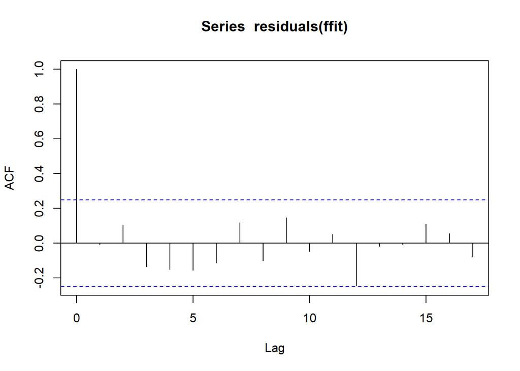

```r
acf(residuals(ffit))
```

Finally, best regression model is obtained by adding lag. The final model does not have autocorrelated residuals, it does have higher R-squared value and it does have less residual standard error.

## Further Visualiation

Residuals of the final model could be interpreted by the chart below. (Fitted vs Residual)

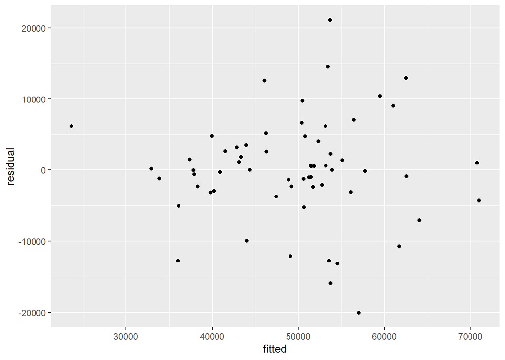

Unfortunately there are a few outliers which may bring model to fail but there is no precaution to be taken.

This is sale quantity vs fitted values:

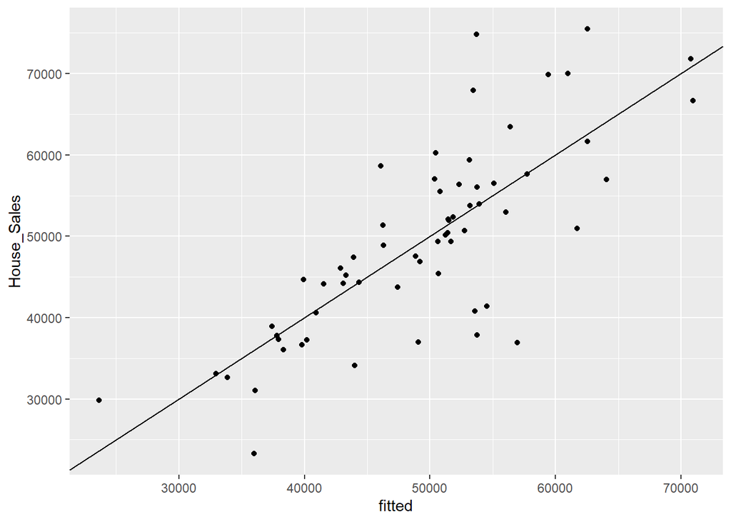

Except a few points, values are distributed around x=y line.

Below is the line graph:

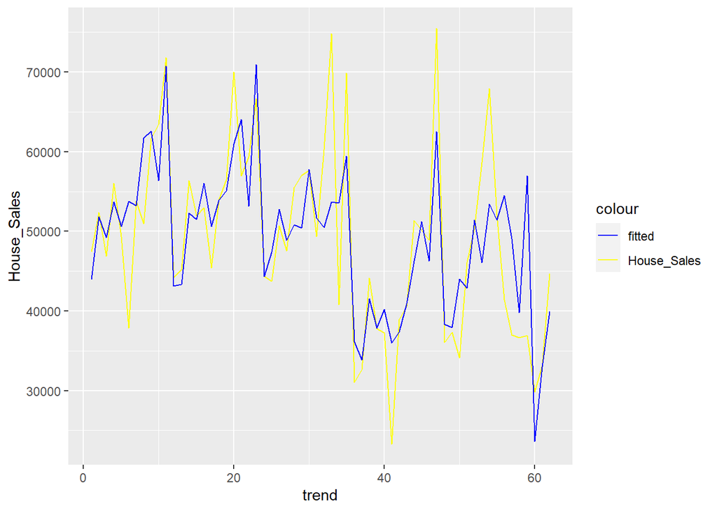

## Forecasting of April 2021

This is the forecasted quantity of sales:

```
##      64
## 28091.4
```

And lastly, prediction vs actual quantity is shown below:

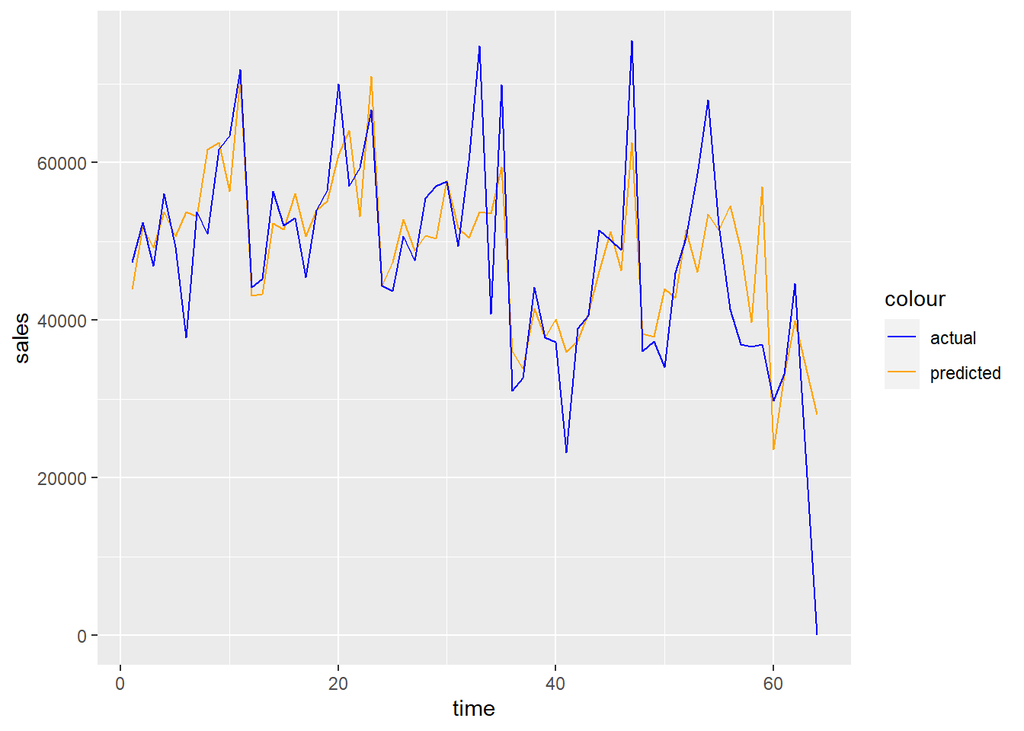